# Deng data: learn more about the blastocyst stages

Joyce Hsiao

2016-10-01

## Objectives

In this document, we try out alterantive visualizations to learn about the GoM clusters in the Deng Structure plot with K=6 (excluding Actb). We removed the blastycyst stage labels and re-ordered the cell samples in the blastocyst stages based on the topic proportion of the dominant cluster.

## Summary of findings

As expected, the updated Structure plot revealed a continuous variation of grades of membership across cell samples in the blastocyst stages. The purple cluster is the dominant cluster among the three clusters in the blastocyst stages. We further use the re-ordered blastocyst labels to visualize the expression heatmap.

We then normalized the expression levels using the endogeneous control genes and made several expression heatmaps: normlaized with respect to the average of Actb and Gadph, normalized with respect to Actb, and normalized with respect to Gadph.

## Setting up

Load packages

Load Deng data

```r
library(singlecellRNAseqData)
MouseDengESC <- get(data("MouseDengESC"))
meta_data <- pData(MouseDengESC)
```

Compute index variable for the blastocyst cell samples

```r
is_blastocyst <- which(meta_data$cell_type == "earlyblast"|
                        meta_data$cell_type == "midblast" |
                        meta_data$cell_type == "lateblast")
```

Import list of 48 genes identified in Guo et al.

```r
guo_genes <- c("Creb3l2", "Tcf23", "Snai1", "Pdgfra", "Gata4", "Sox13",
               "Klf5", "Tcfap2c", "Gapdh", "Actb", "Pdgfa", "Msc", "Hand1",
               "Runx1", "Gata6", "Fgfr2", "Dab2", "Msx2", "Hnf4a", "Pou5f1",
               "Utf1", "Sall4", "Ahcy", "Sox17", "Klf4", "Fgf4", "Klf2",
               "Esrrb", "Nanog", "Bmp4", "Sox2", "Fn1", "Pecam1", "Tspan8",
               "Dppa1", "Lcp1", "Aqp3", "Id2", "Krt8", "Cebpa", "Eomes",
               "Gata3", "Mbnl3", "Tcfap2a", "Grhl1", "Atp12a", "Grhl2", "Cdx2")
```

Normalize the count data. Use the method implemented in voom/limma.

```r
counts <- exprs(MouseDengESC)
lib_size <- colSums(counts)
expr_log2cpm <- t(log2(t(counts + 0.5)/(lib_size + 1) * 1e+06))
```

Create a subset of 48 genes included in Guo et al., 2010.

```r
ind_match <- match(guo_genes, rownames(counts))

expr_log2cpm_guo <- expr_log2cpm[ind_match,]
```

Load GoM results without ACTB. These results were previously computed by Kushal.

```r
load("../rdas/topic_clus_no_Actb_deng.rda")
```

## Structure plots

Combine all blastocyst stages

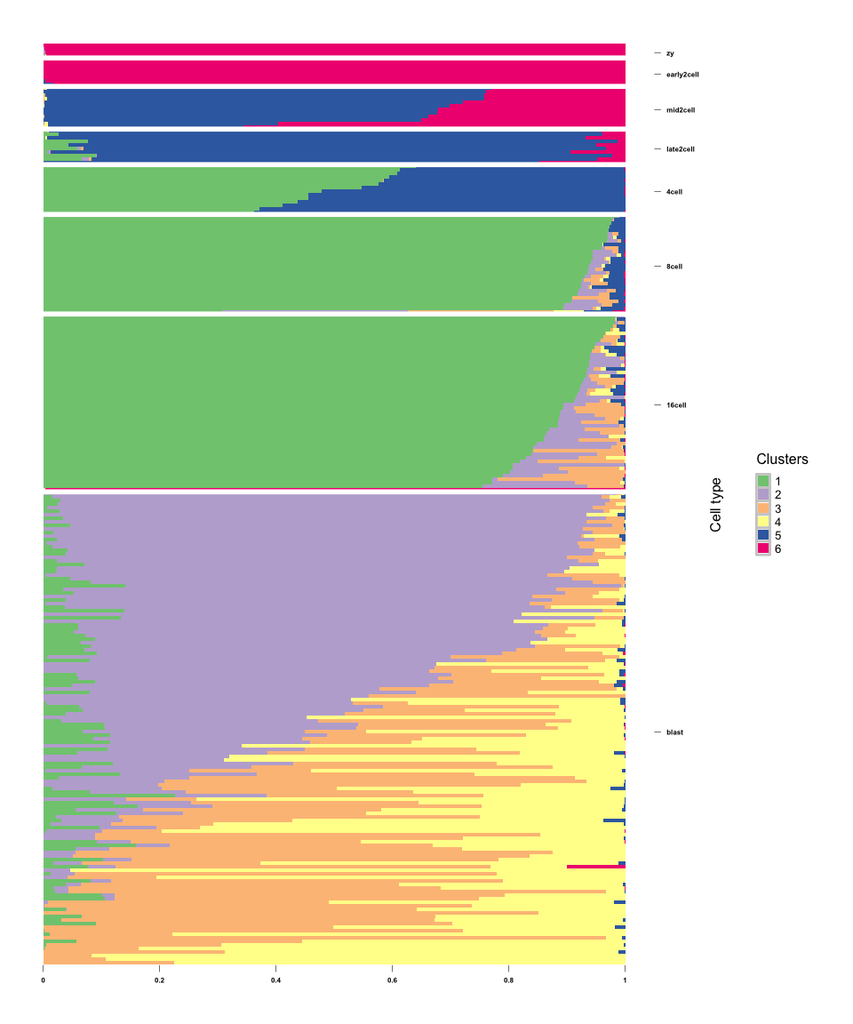

```r
cell_type_blast <- as.character(meta_data$cell_type)
cell_type_blast[grep("blast", cell_type_blast)] <- "blast"
cell_type_blast <- factor(cell_type_blast,
      levels = rev(c("zy", "early2cell", "mid2cell", "late2cell",
                 "4cell", "8cell", "16cell", "blast")))
StructureGGplot(omega = topic_clus$omega,
    annotation = data.frame(
                   sample_id = paste0("X", c(1:NROW(topic_clus$omega))),
                   tissue_label = cell_type_blast),
               palette = RColorBrewer::brewer.pal(8, "Accent"),
               figure_title = "",
               yaxis_label = "Cell type",
               sample_order_decreasing = FALSE)
```

Extract the cell sample order in the previous Structure plot.

```r
source("../R/StructureGGplot-simple.R")
df_mlt <- StructureGGplot_simple(omega = topic_clus$omega,
    annotation = data.frame(
                   sample_id = paste0("X", c(1:NROW(topic_clus$omega))),
                   tissue_label = cell_type_blast),
               palette = RColorBrewer::brewer.pal(8, "Accent"),
               figure_title = "",
               yaxis_label = "Cell type",
               sample_order_decreasing = FALSE)
structure_order_blast <- rev(as.character(df_mlt$document[!duplicated(df_mlt$document)])[1:133])
```

### log2CPM expression heatmap

Heatmap of marker genes. Order the cell samples by the previous Structure plot.

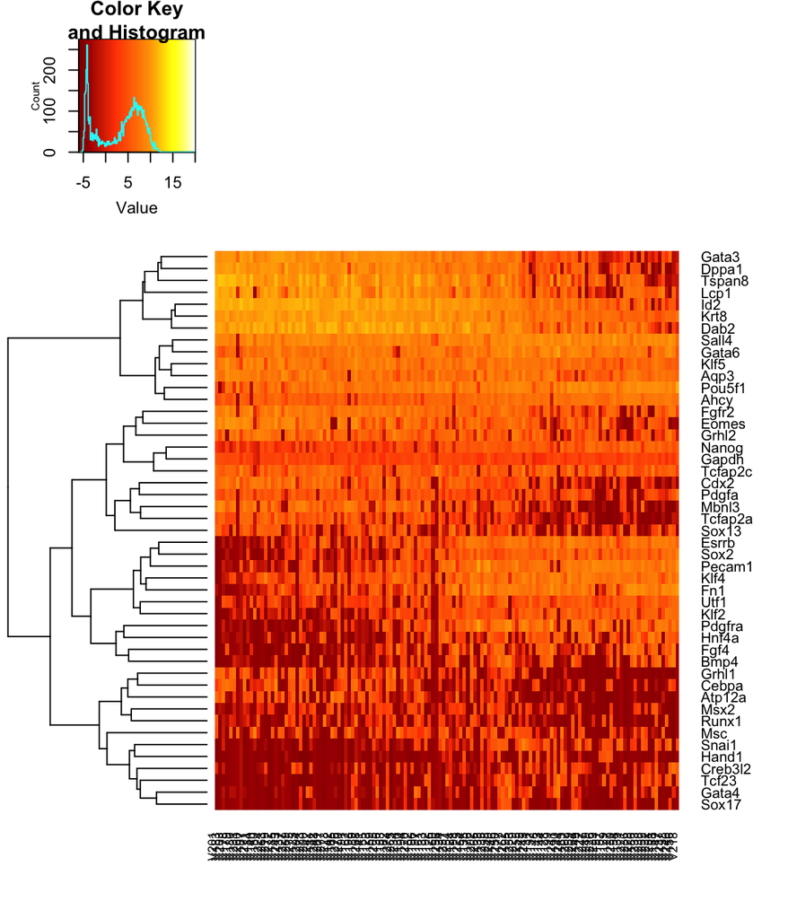

```r
colors <- c(seq(-6,10,length=100),seq(10,20,length=100))
colors <- colors[!duplicated(colors)]
my_palette <- colorRampPalette(
    c("white", "yellow", "orange", "orangered", "red4"))(n = length(colors)-1)

#prop_clust4 <- topic_clus$omega[is_blastocyst,4]
# labels_col <- substr(meta_data$cell_type[is_blastocyst], 1, 3)[order(prop_clust4)]
xx <- as.matrix(expr_log2cpm_guo[,is_blastocyst])

ind_notACTB <- !(rownames(xx) %in% c("Actb"))
gplots::heatmap.2(xx[ind_notACTB, rev(structure_order_blast)],
                  breaks = colors,
                  col = rev(my_palette),
                  #labCol = "",
                  trace = "none",
                  dendrogram = "row", Colv = FALSE,
                  symm=F,symkey=F,symbreaks=T, scale="none",
                  main = "")
```

### log2CPM relative expression heatmap

Summary of expression levels of the control genes in the blastocyst stage cell samples

```r
summary(counts[rownames(counts) == "Actb",is_blastocyst])
```

```
   Min. 1st Qu.  Median    Mean 3rd Qu.    Max.
   2106   77610  129300  158200  203800  694000
```

```r
summary(counts[rownames(counts) == "Gapdh",is_blastocyst])
```

```
   Min. 1st Qu.  Median    Mean 3rd Qu.    Max.
    6.0    69.0   123.0   135.2   174.0   466.0
```

#### Average of Actb and Gadph

We computed relative expression levels by subtracting the average logCPM values of Actb and Gadph from each gene’s logCPM.

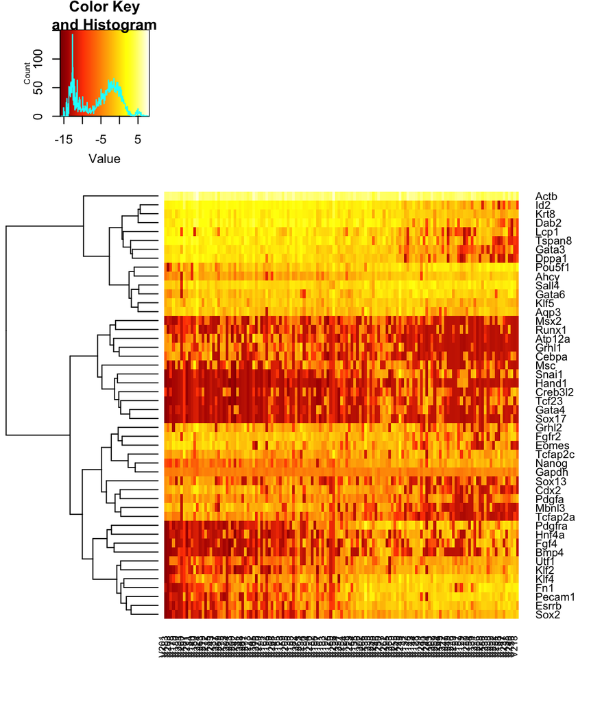

```r
xx <- as.matrix(expr_log2cpm_guo[,is_blastocyst])
control_mean <- 0.5*(xx[rownames(xx) == "Actb",] + xx[rownames(xx) == "Gapdh",])
xx_norm <- t(apply(xx, 1, function(x) x - control_mean))

colors <- seq(-16,8,length=300)
colors <- colors[!duplicated(colors)]
my_palette <- colorRampPalette(
    c("white", "yellow", "orange", "orangered", "red4"))(n = length(colors)-1)

gplots::heatmap.2(xx_norm[, rev(structure_order_blast)],
                  breaks = colors,
                  col = rev(my_palette),
                  #labCol = "",
                  trace = "none",
                  dendrogram = "row", Colv = FALSE,
                  symm=F,symkey=F,symbreaks=T, scale="none",
                  main = "")
```

#### To Actb

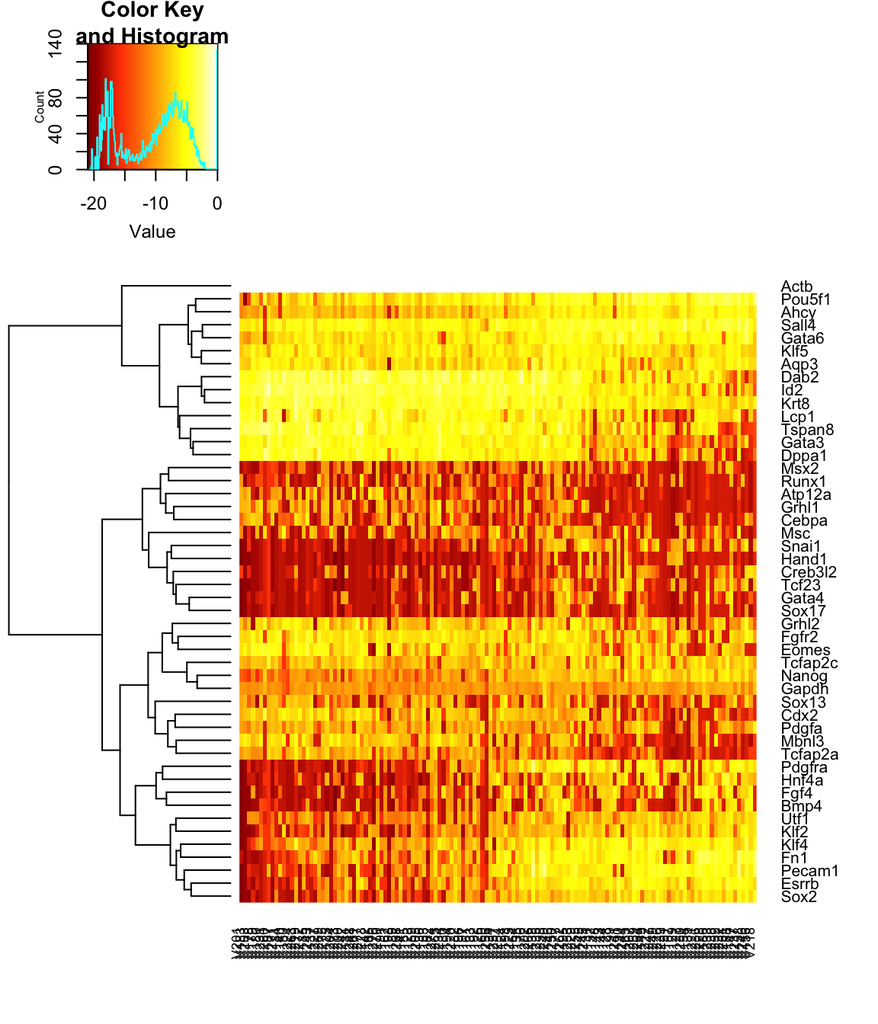

```r
xx <- as.matrix(expr_log2cpm_guo[,is_blastocyst])
xx_norm <- t(apply(xx, 1, function(x) x - xx[rownames(xx) == "Actb",]))

colors <- seq(-21,0,length=200)
colors <- colors[!duplicated(colors)]
my_palette <- colorRampPalette(
    c("white", "yellow", "orange", "orangered", "red4"))(n = length(colors)-1)

gplots::heatmap.2(xx_norm[, rev(structure_order_blast)],
                  breaks = colors,
                  col = rev(my_palette),
                  #labCol = "",
                  trace = "none",
                  dendrogram = "row", Colv = FALSE,
                  symm=F,symkey=F,symbreaks=T, scale="none",
                  main = "")
```

#### To Gadph

Because Actb is very highly expressed across cell samples, we use only Gadph to compute relative expression levels.

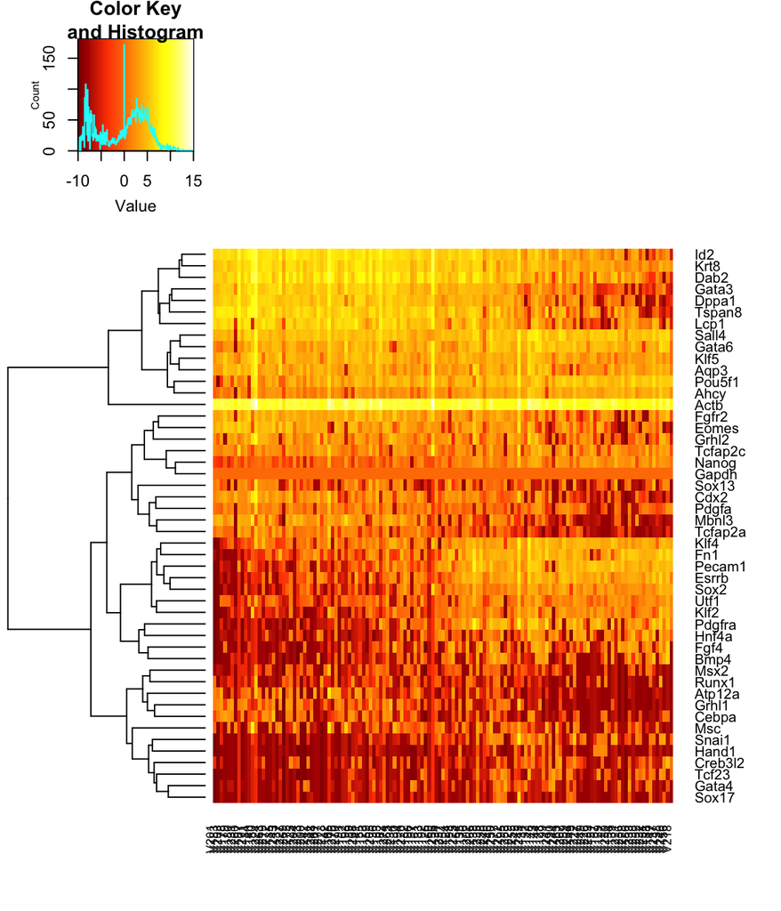

```r
xx <- as.matrix(expr_log2cpm_guo[,is_blastocyst])
xx_norm <- t(apply(xx, 1, function(x) x - xx[rownames(xx) == "Gapdh",]))

colors <- seq(-10,15,length=250)
colors <- colors[!duplicated(colors)]
my_palette <- colorRampPalette(
    c("white", "yellow", "orange", "orangered", "red4"))(n = length(colors)-1)

gplots::heatmap.2(xx_norm[, rev(structure_order_blast)],
                  breaks = colors,
                  col = rev(my_palette),
                  #labCol = "",
                  trace = "none",
                  dendrogram = "row", Colv = FALSE,
                  symm=F,symkey=F,symbreaks=T, scale="none",
                  main = "")
```

Take out Actb and Gadph when making heatmap.

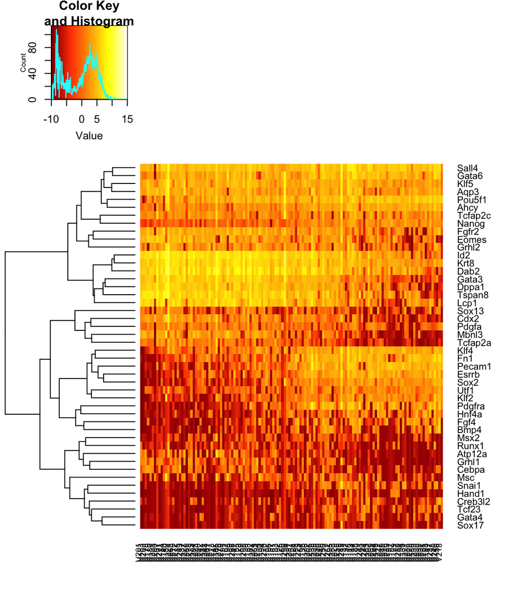

```r
xx <- as.matrix(expr_log2cpm_guo[,is_blastocyst])
xx_norm <- t(apply(xx, 1, function(x) x - xx[rownames(xx) == "Gapdh",]))

gplots::heatmap.2(xx_norm[!(rownames(xx_norm) %in% c("Actb", "Gapdh")),
                          rev(structure_order_blast)],
                  breaks = colors,
                  col = rev(my_palette),
                  #labCol = "",
                  trace = "none",
                  dendrogram = "row", Colv = FALSE,
                  symm=F,symkey=F,symbreaks=T, scale="none",
                  main = "")
```

## Blastocyst labels

Summarize the blastocyst stages of the cell samples in the re-ordered dataset.

```r
meta_data_blast <- meta_data[grep("blast", meta_data$cell_type),]
meta_data_blast <- meta_data_blast[ match(rev(structure_order_blast), rownames(meta_data_blast)), ]
```

Make barplot to indicate blastocyst stages

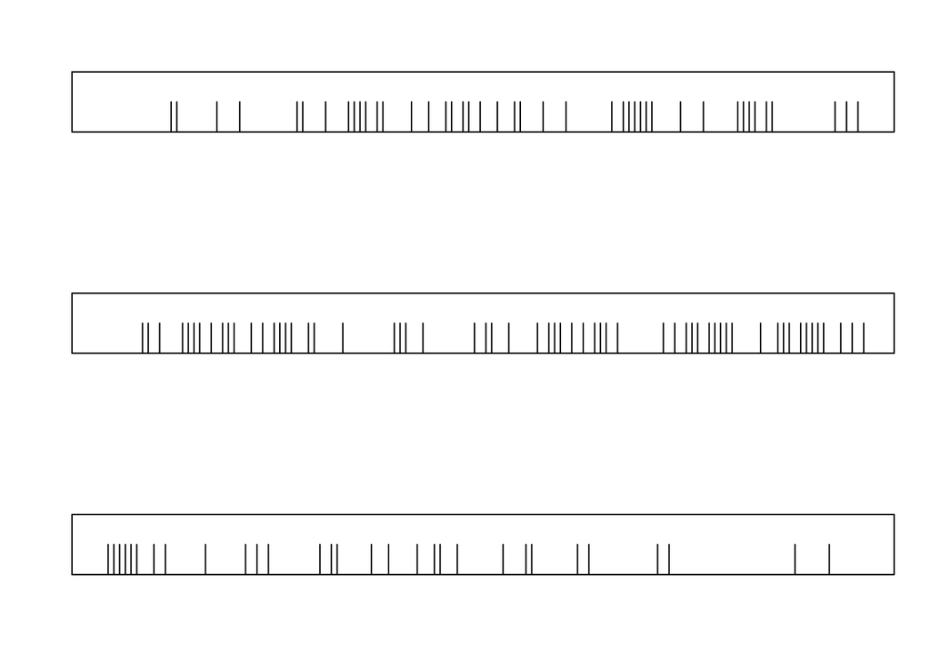

```r
par(mfrow = c(3,1))
for (i in c("earlyblast", "midblast", "lateblast")) {
    plot(x = which(meta_data_blast$cell_type == i),
         y = rep(1, length(which(meta_data_blast$cell_type == i))),
         type = "h", ann = FALSE, xaxt = "n", yaxt = "n",
         xlim = c(0,133))
}
```